None

# 4.2. Машинное обучение и предобработка данных

выполнил студент: Морозов Е.А.

## Постановка задачи.

Машинное обучение является одним из самых перспективных направлений в IT. В данной практической работе рассматривались следующие темы: различные способы предобработки данных, подготовка данных перед их подачей в модель, популярные и основные алгоритмы и задачи машинного обучения.

Источник данных (kaggle loan defaulter dataset): https://www.kaggle.com/datasets/gauravduttakiit/loan-defaulter/application_data.csv

### Ход работы.

1. Загрузите данные.
2. Сделайте предобработку данных.
3. Сделайте снижение размерности для визуализации данных. Опишите, почему вы выбрали именно данный метод снижения размерности и почему задали именно такие параметры.
4. Обучите модель классификации. Выведите метрики. Опишите почему вы выбрали именно эту модель и именно такие ее параметры.
5. Сделайте выводы.

## Исследование.

Загрузим и проанализируем данные.

Датасет на странице соревнования представлен в разделённом 2 части виде, использовались лишь файлы "application_data.csv" и "columns_description.csv". Данные представлены в табличном виде, описание и анализ содержащихся признаков представлены ниже.

### Загрузка, импорты. Описание данных. EDA.

Сделаем импорты, установим компоненты для работы, опишем и проанализируем наблюдаемые данные.

```python
# импортируем библиотеки:
import matplotlib.pyplot as plt
import numpy as np
import pandas as pd
import seaborn as sns
sns.set_style('whitegrid')
np.set_printoptions(precision=4)
from random import sample

from sklearn.compose import ColumnTransformer, make_column_selector
from sklearn.decomposition import PCA
from sklearn.dummy import DummyClassifier
from sklearn.ensemble import RandomForestClassifier
from sklearn.feature_selection import VarianceThreshold, mutual_info_classif, SelectKBest, chi2

from sklearn.neighbors import KNeighborsClassifier
from sklearn.linear_model import LogisticRegression
from sklearn.inspection import permutation_importance
from sklearn.metrics import f1_score, roc_auc_score, roc_curve, precision_score, recall_score,\
                            precision_recall_curve, accuracy_score, auc, classification_report, \
                            confusion_matrix, ConfusionMatrixDisplay

from sklearn.model_selection import train_test_split, RandomizedSearchCV, cross_val_score, GridSearchCV
from sklearn.pipeline import Pipeline, FeatureUnion
from sklearn.preprocessing import StandardScaler, OneHotEncoder, OrdinalEncoder

# отключим предупреждения:
import warnings
warnings.simplefilter('ignore')
pd.options.mode.chained_assignment = None # чтобы избавиться от конфликта pandas и sklearn

# зададим состояние генератора случайных чисел для исползуемых объектов:
state = np.random.RandomState(606)
#np.random.seed(606) - не работал как хотелось, не понял почему
```

Таблица изначально объемная с большим количеством объектов и признаков, в этой связи описание данных приводится не в 1-ой части работы, а из прилагающегося к датасету файла с описаниями колонок таблицы.

```python
pd.read_csv('./4_2_data/columns_description.csv')
```

|  | Unnamed: 0 | Table | Row | Description | Special |
| --- | --- | --- | --- | --- | --- |
| 0 | 1 | application_data | SK_ID_CURR | ID of loan in our sample | NaN |
| 1 | 2 | application_data | TARGET | Target variable (1 - client with payment diffi... | NaN |
| 2 | 5 | application_data | NAME_CONTRACT_TYPE | Identification if loan is cash or revolving | NaN |
| 3 | 6 | application_data | CODE_GENDER | Gender of the client | NaN |
| 4 | 7 | application_data | FLAG_OWN_CAR | Flag if the client owns a car | NaN |
| ... | ... | ... | ... | ... | ... |
| 155 | 209 | previous_application.csv | DAYS_FIRST_DUE | Relative to application date of current applic... | time only relative to the application |
| 156 | 210 | previous_application.csv | DAYS_LAST_DUE_1ST_VERSION | Relative to application date of current applic... | time only relative to the application |
| 157 | 211 | previous_application.csv | DAYS_LAST_DUE | Relative to application date of current applic... | time only relative to the application |
| 158 | 212 | previous_application.csv | DAYS_TERMINATION | Relative to application date of current applic... | time only relative to the application |
| 159 | 213 | previous_application.csv | NFLAG_INSURED_ON_APPROVAL | Did the client requested insurance during the ... | NaN |

160 rows × 5 columns

```python
# загрузим датафрейм
df = pd.read_csv('./4_2_data/application_data.csv')
print(df.info())
df.sample(5)
```

```
<class 'pandas.core.frame.DataFrame'>
RangeIndex: 307511 entries, 0 to 307510
Columns: 122 entries, SK_ID_CURR to AMT_REQ_CREDIT_BUREAU_YEAR
dtypes: float64(65), int64(41), object(16)
memory usage: 286.2+ MB
None
```

|  | SK_ID_CURR | TARGET | NAME_CONTRACT_TYPE | CODE_GENDER | FLAG_OWN_CAR | FLAG_OWN_REALTY | CNT_CHILDREN | AMT_INCOME_TOTAL | AMT_CREDIT | AMT_ANNUITY | ... | FLAG_DOCUMENT_18 | FLAG_DOCUMENT_19 | FLAG_DOCUMENT_20 | FLAG_DOCUMENT_21 | AMT_REQ_CREDIT_BUREAU_HOUR | AMT_REQ_CREDIT_BUREAU_DAY | AMT_REQ_CREDIT_BUREAU_WEEK | AMT_REQ_CREDIT_BUREAU_MON | AMT_REQ_CREDIT_BUREAU_QRT | AMT_REQ_CREDIT_BUREAU_YEAR |
| --- | --- | --- | --- | --- | --- | --- | --- | --- | --- | --- | --- | --- | --- | --- | --- | --- | --- | --- | --- | --- | --- |
| 146003 | 269292 | 0 | Cash loans | F | N | Y | 2 | 139500.0 | 327024.0 | 21852.0 | ... | 0 | 0 | 0 | 0 | 0.0 | 0.0 | 0.0 | 1.0 | 0.0 | 3.0 |
| 290967 | 437071 | 0 | Cash loans | M | Y | N | 0 | 103500.0 | 239850.0 | 22554.0 | ... | 1 | 0 | 0 | 0 | 0.0 | 0.0 | 0.0 | 0.0 | 0.0 | 2.0 |
| 225073 | 360699 | 0 | Cash loans | F | N | N | 0 | 166500.0 | 598486.5 | 19908.0 | ... | 0 | 0 | 0 | 0 | 0.0 | 0.0 | 0.0 | 0.0 | 2.0 | 3.0 |
| 96173 | 211653 | 0 | Cash loans | F | N | Y | 0 | 189000.0 | 1546020.0 | 42642.0 | ... | 0 | 0 | 0 | 0 | 0.0 | 0.0 | 0.0 | 0.0 | 0.0 | 0.0 |
| 127530 | 247906 | 0 | Revolving loans | M | Y | Y | 2 | 270000.0 | 540000.0 | 27000.0 | ... | 0 | 0 | 0 | 0 | 0.0 | 0.0 | 0.0 | 2.0 | 0.0 | 0.0 |

5 rows × 122 columns

### Дубликаты и пропуски.

Таблица с данными весьма объёмная: 307.5К записей в >120 столбцах - содерижит как числовые значения, так и категориальные. Содержание пропусков и дубликатов рассматривается ниже и выполнено прежде остальной обработки, поскольку с отсутствующими данными модели адекватно работать не в состоянии. Количество признаков явно избыточно для обучения моделей, проявится тяга к переобучению и случайному характеру предсказаний на тестовой выборке.

```python
# проверим количество дубликатов
df.duplicated().sum()
```

```
0
```

```python
# проверим пропуски
nan_df = pd.DataFrame(df.isna().sum().sort_values(ascending=False), columns=['NaN_count'])
nan_df['ratio_%'] = 100*np.round(nan_df['NaN_count']/df.shape[0], 3)
nan_df.index.set_names('columns', inplace=True)

# примем процент пропусков, который будем считать критичным
top_nan_df = nan_df[nan_df['ratio_%']>10]
print(f"Столбцы таблицы данных с содержанием пропусков > 10% ({top_nan_df.shape[0]} шт.):")
top_nan_df
```

```
Столбцы таблицы данных с содержанием пропусков > 10% (57 шт.):
```

| columns | NaN_count | ratio_% |
| --- | --- | --- |
| COMMONAREA_MEDI | 214865 | 69.9 |
| COMMONAREA_AVG | 214865 | 69.9 |
| COMMONAREA_MODE | 214865 | 69.9 |
| NONLIVINGAPARTMENTS_MODE | 213514 | 69.4 |
| NONLIVINGAPARTMENTS_AVG | 213514 | 69.4 |
| NONLIVINGAPARTMENTS_MEDI | 213514 | 69.4 |
| FONDKAPREMONT_MODE | 210295 | 68.4 |
| LIVINGAPARTMENTS_MODE | 210199 | 68.4 |
| LIVINGAPARTMENTS_AVG | 210199 | 68.4 |
| LIVINGAPARTMENTS_MEDI | 210199 | 68.4 |
| FLOORSMIN_AVG | 208642 | 67.8 |
| FLOORSMIN_MODE | 208642 | 67.8 |
| FLOORSMIN_MEDI | 208642 | 67.8 |
| YEARS_BUILD_MEDI | 204488 | 66.5 |
| YEARS_BUILD_MODE | 204488 | 66.5 |
| YEARS_BUILD_AVG | 204488 | 66.5 |
| OWN_CAR_AGE | 202929 | 66.0 |
| LANDAREA_MEDI | 182590 | 59.4 |
| LANDAREA_MODE | 182590 | 59.4 |
| LANDAREA_AVG | 182590 | 59.4 |
| BASEMENTAREA_MEDI | 179943 | 58.5 |
| BASEMENTAREA_AVG | 179943 | 58.5 |
| BASEMENTAREA_MODE | 179943 | 58.5 |
| EXT_SOURCE_1 | 173378 | 56.4 |
| NONLIVINGAREA_MODE | 169682 | 55.2 |
| NONLIVINGAREA_AVG | 169682 | 55.2 |
| NONLIVINGAREA_MEDI | 169682 | 55.2 |
| ELEVATORS_MEDI | 163891 | 53.3 |
| ELEVATORS_AVG | 163891 | 53.3 |
| ELEVATORS_MODE | 163891 | 53.3 |
| WALLSMATERIAL_MODE | 156341 | 50.8 |
| APARTMENTS_MEDI | 156061 | 50.7 |
| APARTMENTS_AVG | 156061 | 50.7 |
| APARTMENTS_MODE | 156061 | 50.7 |
| ENTRANCES_MEDI | 154828 | 50.3 |
| ENTRANCES_AVG | 154828 | 50.3 |
| ENTRANCES_MODE | 154828 | 50.3 |
| LIVINGAREA_AVG | 154350 | 50.2 |
| LIVINGAREA_MODE | 154350 | 50.2 |
| LIVINGAREA_MEDI | 154350 | 50.2 |
| HOUSETYPE_MODE | 154297 | 50.2 |
| FLOORSMAX_MODE | 153020 | 49.8 |
| FLOORSMAX_MEDI | 153020 | 49.8 |
| FLOORSMAX_AVG | 153020 | 49.8 |
| YEARS_BEGINEXPLUATATION_MODE | 150007 | 48.8 |
| YEARS_BEGINEXPLUATATION_MEDI | 150007 | 48.8 |
| YEARS_BEGINEXPLUATATION_AVG | 150007 | 48.8 |
| TOTALAREA_MODE | 148431 | 48.3 |
| EMERGENCYSTATE_MODE | 145755 | 47.4 |
| OCCUPATION_TYPE | 96391 | 31.3 |
| EXT_SOURCE_3 | 60965 | 19.8 |
| AMT_REQ_CREDIT_BUREAU_HOUR | 41519 | 13.5 |
| AMT_REQ_CREDIT_BUREAU_DAY | 41519 | 13.5 |
| AMT_REQ_CREDIT_BUREAU_WEEK | 41519 | 13.5 |
| AMT_REQ_CREDIT_BUREAU_MON | 41519 | 13.5 |
| AMT_REQ_CREDIT_BUREAU_QRT | 41519 | 13.5 |
| AMT_REQ_CREDIT_BUREAU_YEAR | 41519 | 13.5 |

Столбцы с таким количеством пропусков удалим чтобы, не заполнять их и не разбираться в значениях излишне долго, скорее всего это аггрегированные данные полученные на основании информации из других столбцов таблицы при её обработке в БД с использованием данных о времени, модели вполне способны приобрести обобщающую способность на оставшихся данных, поскольку их всё также много. Если потребуется, то можно будет извлечь признаки из столбца с временными данными отдельно.

```python
# удаляем толбцы с большим кол-вом пропусков
df.drop(columns=top_nan_df.index, inplace=True)
df.isna().sum().sort_values(ascending=False).head(11)
```

```
NAME_TYPE_SUITE             1292
OBS_30_CNT_SOCIAL_CIRCLE    1021
DEF_30_CNT_SOCIAL_CIRCLE    1021
OBS_60_CNT_SOCIAL_CIRCLE    1021
DEF_60_CNT_SOCIAL_CIRCLE    1021
EXT_SOURCE_2                 660
AMT_GOODS_PRICE              278
AMT_ANNUITY                   12
CNT_FAM_MEMBERS                2
DAYS_LAST_PHONE_CHANGE         1
FLAG_DOCUMENT_4                0
dtype: int64
```

```python
# удаляем записи с пропусками
df.dropna(axis=0, inplace=True)
df.shape
```

```
(304531, 65)
```

Для машинного обучения такое количество признаков по-прежнему кажется избыточны и потребует большого объёма предообработки (от заполнения пропусков и исправления ошибок до кодирования переменных и анализа значимости), что растянет время подготовки и сделает этап отбора сложным в смысле написания большого конвейера предобработки. Нужно выработать подходы к отбору признаков для сокращения их чилса.

### Анализ признаков, отбор, сокращение.

Выполнение задач этого пункта сопряжено с разведочным анализом данных, они будут пересекаться. Разделять выборук на признаки и целевой признак и на обучающую и тестовую части пока не станем, поскольку на данном этапе можно будет "отбросить" признаки из всей выборки сразу не опасаясь утечек, а после этого провести разделения.

Признаки могут демонстировать разной силы и природы связь между собой и с целевым признаком в зависимости от сочетаний из пары {категориальный тип данных; числовой тип данных}. Связь может быть как линейной, так и нелинейной, может отрицательной или остутствовать вовсе и в этой связи оценивать их полезность нужно отдельно и различными способами. Можно следовать согласно схеме, приведённой ниже.

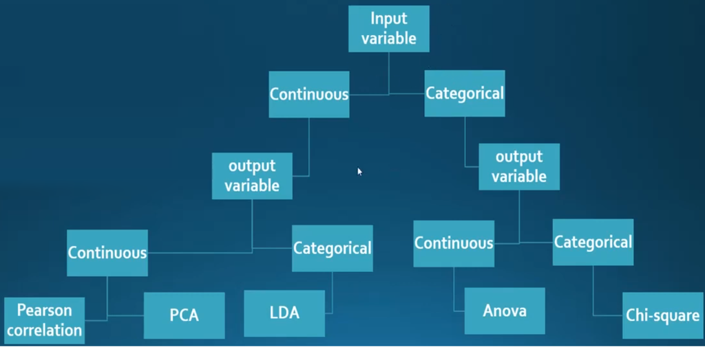

Используем некоторые пункты как основу для отбора признаков и проведём анализ:

- корреляционный анализ числовых признаков,
- дисперсионный анализ (не для целевого признака),
- критерий **chi2** для категориальных признаков и целевого признака,
- анализ информативности,
- компонентный анализ (как для иллюстрирования, так и для снижения кол-ва признаков).

#### Корреляционный анализ.

Быстрее всего рассмотреть линейные связи числовых признаков и удалить наиболее сильные чтобы избежать коллинеарности.

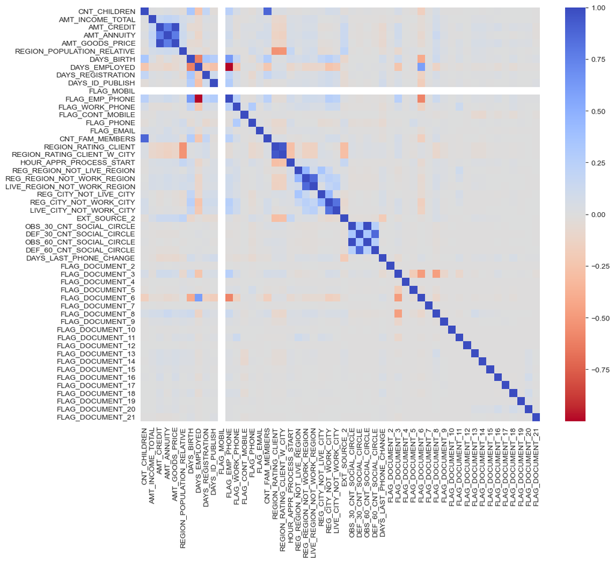

```python
# рассмотрим матрицу корреляций (Pearson Correlation)
plt.figure(figsize=(12,10))
sns.heatmap(df.drop(columns=['SK_ID_CURR','TARGET']).corr()
            , cbar=True
            , annot=False
            , cmap=plt.cm.coolwarm_r)
plt.show()
```

```python
corr_df = df.corr()

# функция для отбора признаков с высокой коррляцией

def correlation(dataset, threshold):
    col_corr = []
    corr_matrix = dataset.corr()
    for i in range(len(corr_matrix.columns)):
        for j in range(i):
            if corr_matrix.iloc[i, j] > threshold: # сравниваем не по модулю, т.к. отриц.
                                                   # корреляции могут нести инфомрацию для
                                                   # обучения моделей (предположительно)
                colname = corr_matrix.columns[i]   # получаем название столбца
                col_corr.append(colname)
    return col_corr

# выводим список сильно-скореллированных столбцов и удаляем их
f_correlated = correlation(corr_df, 0.75)
print('Признаки с наибольшими корреляциями:')
pd.Series(f_correlated, index=range(len(f_correlated)))
```

```
Признаки с наибольшими корреляциями:
```

```
0                     AMT_ANNUITY
1                 AMT_GOODS_PRICE
2                 AMT_GOODS_PRICE
3                  FLAG_EMP_PHONE
4                 CNT_FAM_MEMBERS
5     REGION_RATING_CLIENT_W_CITY
6     LIVE_REGION_NOT_WORK_REGION
7         LIVE_CITY_NOT_WORK_CITY
8        OBS_60_CNT_SOCIAL_CIRCLE
9        DEF_60_CNT_SOCIAL_CIRCLE
10                FLAG_DOCUMENT_6
dtype: object
```

```python
df.drop(columns=f_correlated, inplace=True)
df.shape
```

```
(304531, 55)
```

#### Проверка стационарности.

После корр.анализа количество признаков вновь уменьшилось за счёт удаления столбцов с числовыми типами данных. Однако также стоит проверить столбцы и на стационарность содержащихся значений, т.к. банальная логика подсказывает, что если в столбце напротив всех объектов содержится лишь одно неизменное значение или единицы раз встречается ещё несколько других значений, то сомнительно что подобный признак окажется полезным. Будем либо такие строки стоит считать выбросными, либо удалять "стационарный" столбец целиком.

```python
# признаки zero-variance
var_thres=VarianceThreshold(threshold=0)

# fit на числовые признаки и выводим список с True/False значениями
var_thres.fit(df.select_dtypes(include=['float','int']))
var_thres.get_support()   # столбцы с False стационарны
```

```
array([ True,  True,  True,  True,  True,  True,  True,  True,  True,
        True, False,  True,  True,  True,  True,  True,  True,  True,
        True,  True,  True,  True,  True,  True,  True,  True,  True,
        True,  True,  True,  True,  True,  True,  True,  True,  True,
        True,  True,  True,  True,  True,  True,  True,  True])
```

```python
# отфильтровываем и удаляем столбцы
num_cols = df.select_dtypes(include=['float','int']).columns.values
constant_columns = [column for column in num_cols
                    if column not in df.select_dtypes(include=['float','int'])
                                       .columns[var_thres.get_support()]]
print(f'Стационарных признаков: {len(constant_columns)} шт. -', *constant_columns)
print('Признаков до удаления -', df.shape[1])
df.drop(columns=constant_columns, inplace=True)
print('Признаков после удаления -', df.shape[1])
```

```
Стационарных признаков: 1 шт. - FLAG_MOBIL
Признаков до удаления - 55
Признаков после удаления - 54
```

#### Анализ информативности

Полезность оставшихся признаков можно оценивать с помощью критерия ***взаимной информации*** *— статистической функции двух случайных величин, описывающей количество информации, содержащейся в одной случайной величине относительно другой*. Определяется через энтропию и условную энтропию двух случайных величин как:  
$ I(X;Y)=H(X)-H(X\mid Y)=H(X)+H(Y)-H(X,Y)$

Соотв. классы описаны в библиотеке `sklearn`, вызовем их и обучим на столбцах датафрейма.

- Однако для получения значений энтропии по всем столбцам текстовые значения категориальных переменных придётся перекодировать в числовые.
- Преобразования выполняются пока что для всей выборки целиком, поскольку целью является выявление признаков, которые можно удалить как недостаточно информативные для обучения моделей.
- Ограничиться использованием только прямого кодирования с пом. **LabelEncoder()** не вышло поскольку он не поддерживает 2D-массивы данных на входе и преназначен для работы с целевым признаком (1D-массив). Для обработки признаков использовался **OrdinalEncoder()**.

```python
# разделим признаки по категориям
cat_features = df.select_dtypes(include='object').columns.values     # категориальные
num_features = df.select_dtypes(include=['float','int']).columns.values    # числовые (только с плав.точкой, целые не масштабируем)
print(cat_features.shape, num_features.shape)
```

```
(11,) (43,)
```

```python
# преобразуем признаки в ColumnTransformer
ct = ColumnTransformer([
     ("text_preprocess", OrdinalEncoder(), cat_features)
    #, ("num_preprocess", MinMaxScaler(), num_features)
], remainder='passthrough')

df_encoded = ct.fit_transform(df.drop(columns=['SK_ID_CURR', 'TARGET']))
df_encoded.shape
```

```
(304531, 52)
```

```python
# определим значения mutual information для перекодированных признаков относительно целевого
mutual_info = mutual_info_classif(
    pd.DataFrame(df_encoded, columns=df.columns[2:]), df['TARGET']
    , random_state=state, n_neighbors=30
)
```

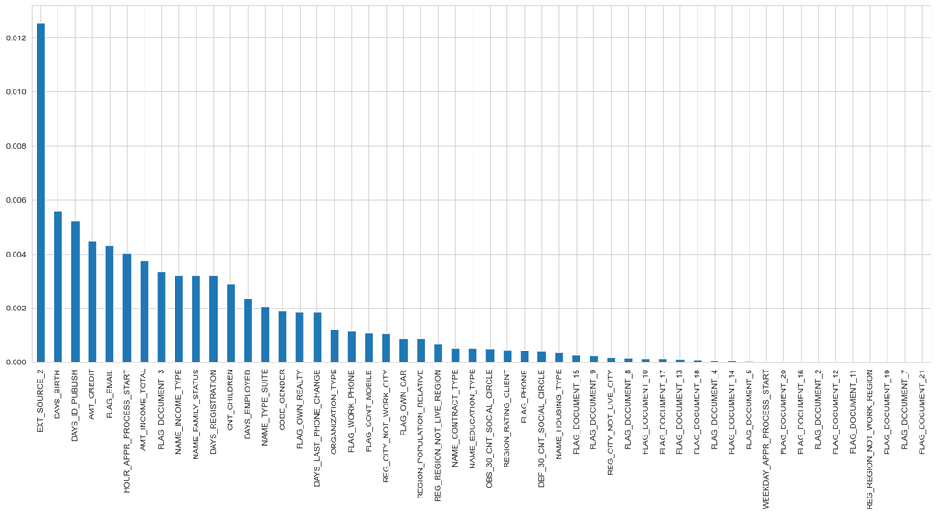

```python
# отсортируем полученные значения взаимной информации и отобразим на диаграмме
mutual_info = pd.Series(mutual_info, index=df.columns[2:])
mutual_info.sort_values(ascending=False).plot.bar(figsize=(20, 8))
plt.show()
```

- На диаграмме наглядно показаны степени информативности признаков, поскольку малые величины взаимной информации легче воспринимаются в таком виде.
- Для примера и судя по диаграмме попробуем остановиться примерно на 30 наиболее информативных признаках с наибольшими значениями взаимной информации.

```python
#top 30 признаков через SelectKBest, чтобы не выставлять и не определять пороги взятия вручную
sel_30_cols = SelectKBest(mutual_info_classif, k=30)
sel_30_cols.fit(df_encoded, df['TARGET'].values)
```

```
SelectKBest(k=30,
            score_func=<function mutual_info_classif at 0x000001DC8318B550>)
```

```python
#из атрибута .get_support() получаем метки является или нет признак значимым
sel_30_cols.get_support()
```

```
array([False,  True,  True,  True,  True,  True,  True,  True,  True,
        True,  True,  True,  True,  True,  True,  True,  True,  True,
        True,  True,  True,  True, False,  True,  True, False, False,
       False,  True,  True,  True,  True,  True, False,  True, False,
       False, False, False,  True, False, False, False, False, False,
       False, False, False, False, False, False, False])
```

```python
#по маске получаем наименования столбцов, учитвая что в df отбрасывались первые 2 столбца
top_30_cols = df[df.columns[2:]].columns[sel_30_cols.get_support()]
top_30_cols
```

```
Index(['CODE_GENDER', 'FLAG_OWN_CAR', 'FLAG_OWN_REALTY', 'CNT_CHILDREN',
       'AMT_INCOME_TOTAL', 'AMT_CREDIT', 'NAME_TYPE_SUITE', 'NAME_INCOME_TYPE',
       'NAME_EDUCATION_TYPE', 'NAME_FAMILY_STATUS', 'NAME_HOUSING_TYPE',
       'REGION_POPULATION_RELATIVE', 'DAYS_BIRTH', 'DAYS_EMPLOYED',
       'DAYS_REGISTRATION', 'DAYS_ID_PUBLISH', 'FLAG_WORK_PHONE',
       'FLAG_CONT_MOBILE', 'FLAG_PHONE', 'FLAG_EMAIL', 'REGION_RATING_CLIENT',
       'HOUR_APPR_PROCESS_START', 'REG_REGION_NOT_LIVE_REGION',
       'ORGANIZATION_TYPE', 'EXT_SOURCE_2', 'OBS_30_CNT_SOCIAL_CIRCLE',
       'DEF_30_CNT_SOCIAL_CIRCLE', 'DAYS_LAST_PHONE_CHANGE', 'FLAG_DOCUMENT_3',
       'FLAG_DOCUMENT_9'],
      dtype='object')
```

```python
#оставляем выбранные столбцы в качестве полезных признаков
df_reduced = pd.concat([df['TARGET'],df[top_30_cols]], axis=1)
df_reduced.head(3)
```

|  | TARGET | CODE_GENDER | FLAG_OWN_CAR | FLAG_OWN_REALTY | CNT_CHILDREN | AMT_INCOME_TOTAL | AMT_CREDIT | NAME_TYPE_SUITE | NAME_INCOME_TYPE | NAME_EDUCATION_TYPE | ... | REGION_RATING_CLIENT | HOUR_APPR_PROCESS_START | REG_REGION_NOT_LIVE_REGION | ORGANIZATION_TYPE | EXT_SOURCE_2 | OBS_30_CNT_SOCIAL_CIRCLE | DEF_30_CNT_SOCIAL_CIRCLE | DAYS_LAST_PHONE_CHANGE | FLAG_DOCUMENT_3 | FLAG_DOCUMENT_9 |
| --- | --- | --- | --- | --- | --- | --- | --- | --- | --- | --- | --- | --- | --- | --- | --- | --- | --- | --- | --- | --- | --- |
| 0 | 1 | M | N | Y | 0 | 202500.0 | 406597.5 | Unaccompanied | Working | Secondary / secondary special | ... | 2 | 10 | 0 | Business Entity Type 3 | 0.262949 | 2.0 | 2.0 | -1134.0 | 1 | 0 |
| 1 | 0 | F | N | N | 0 | 270000.0 | 1293502.5 | Family | State servant | Higher education | ... | 1 | 11 | 0 | School | 0.622246 | 1.0 | 0.0 | -828.0 | 1 | 0 |
| 2 | 0 | M | Y | Y | 0 | 67500.0 | 135000.0 | Unaccompanied | Working | Secondary / secondary special | ... | 2 | 9 | 0 | Government | 0.555912 | 0.0 | 0.0 | -815.0 | 0 | 0 |

3 rows × 31 columns

Корреляционный анализ и проверку стационарности повторно проводить не станем.

#### Критерий Chi2

Значимость категориальных признаков в задаче классификации можно проверить также с помощью критерия **Fisher Score** проведя для тест **Chisquare**. Эту оценку можно использовать для выбора признаков с наибольшими значениями тестовой статистики хи-квадрат, которая должна содержать только неотрицательные признаки, такие как логические значения или частоты относительно классов целевого признака.

Тест хи-квадрат измеряет зависимость между стохастическими переменными, поэтому использование этой функции «отсеивает» признаки, которые с наибольшей вероятностью не зависят от класса и, следовательно, не имеют значения для классификации. Статистика хи-квадрат обычно используется для проверки взаимосвязей между категориальными переменными. Она сравнивает наблюдаемое распределение различных классов целевых объектов Y среди различных категорий объектов с ожидаемым распределением целевых классов независимо от категорий объектов.

Поскольку перекодированные в числовые величины признаки у нас уже есть, то проведём также и данное тестирование.

```python
# разделим признаки по категориям
cat_features_1 = df_reduced.select_dtypes(include='object').columns.values     # категориальные
num_features_1 = df_reduced.select_dtypes(include=['float','int']).columns.values    # числовые
print(cat_features_1.shape, num_features_1.shape)
```

```
(9,) (22,)
```

```python
# преобразуем признаки в ColumnTransformer

ct_1 = ColumnTransformer([
     ("text_preprocess", OrdinalEncoder(), cat_features_1)
    #, ("num_preprocess", MinMaxScaler(), num_features_1)
], remainder='drop')

df_reduced_encoded = pd.DataFrame(
    ct_1.fit_transform(df_reduced.drop(columns=['TARGET']))
    , columns=cat_features_1
)
print(df_reduced_encoded.shape)
```

```
(304531, 9)
```

```python
#выполним chi2 test
## chi2 возращает 2 значения: F-score и p-value
f_p_values=chi2(df_reduced_encoded, df_reduced['TARGET'])
f_p_values
```

```
(array([6.1115e+02, 9.5505e+01, 4.2223e+00, 1.3310e+01, 9.2696e+02,
        4.7672e+02, 6.3285e-03, 2.5660e+02, 4.1864e+03]),
 array([6.2916e-135, 1.4750e-022, 3.9896e-002, 2.6393e-004, 1.3557e-203,
        1.1076e-105, 9.3659e-001, 9.4491e-058, 0.0000e+000]))
```

```python
p_values = pd.Series(f_p_values[1], index=cat_features_1).sort_values(ascending=True)
p_values
```

```
ORGANIZATION_TYPE       0.000000e+00
NAME_INCOME_TYPE       1.355740e-203
CODE_GENDER            6.291614e-135
NAME_EDUCATION_TYPE    1.107582e-105
NAME_HOUSING_TYPE       9.449137e-58
FLAG_OWN_CAR            1.474985e-22
NAME_TYPE_SUITE         2.639264e-04
FLAG_OWN_REALTY         3.989641e-02
NAME_FAMILY_STATUS      9.365937e-01
dtype: float64
```

```python
df_reduced.drop(columns=['ORGANIZATION_TYPE', 'NAME_FAMILY_STATUS'], inplace=True)
df_reduced.shape
```

```
(304531, 29)
```

#### PCA

Сократив количество признаков за счёт прямого удаления из рассматриваемой выборки мы всё-таки продолжаем видеть большое их количество при стольже большом разнообразии, что на имеющемся объёме объектов делает задачу обучения через чур многомерной и наврядли позволит значимо превысить результат случайного классификатора.

- Для сокращения размерности и увеличения плотности информации в признаках используется компонентный анализ, позволяющий перейти от одного признакового пространства в пространство меньшей размерности за счёт выделения новых признаков на основаниии распределений значений в имеющихся.
- Особенно удобен он когда объекты нужно разделять линейно и при слабой интерпретируемости существующих признаков, для удаления же малозначимой информации при сокращении он также используется часто. Недостаток состоит лишь в том, что полученные признаки будут неитерпретируемыми, хотя и позволят проще проводить кластеризицию и разделения, обратные преобразования всю исходную информацию не восстановят.
- По всей видимости стоит учесть также одновременное наличие числовых и категориальных величин в наборе данных. Самым логичным ходом видится их параллельная обработка с объединением в единый набор данных перед подачей в модель. Числовые признаки также стоит нормализовать перед проведение **PCA**, чтобы большие масштабы данных не угнетали малые в итоговом результате.

```
Баланс классов целевого признака.
```

|  | TARGET |
| --- | --- |
| 0 | 91.9% |
| 1 | 8.1% |

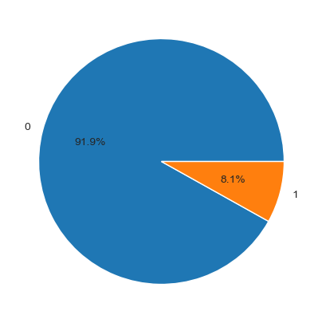

```
Баланс классов категориальных признаков c круговыми диаграммами.

	- столбец CODE_GENDER
```

|  | CODE_GENDER |
| --- | --- |
| F | 65.8% |
| M | 34.2% |
| XNA | 0.0% |

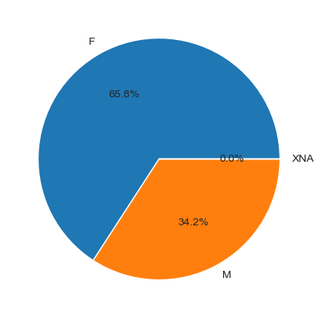

```
	- столбец FLAG_OWN_CAR
```

|  | FLAG_OWN_CAR |
| --- | --- |
| N | 66.0% |
| Y | 34.0% |

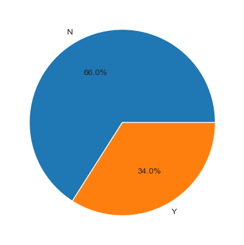

```
	- столбец FLAG_OWN_REALTY
```

|  | FLAG_OWN_REALTY |
| --- | --- |
| Y | 69.5% |
| N | 30.5% |

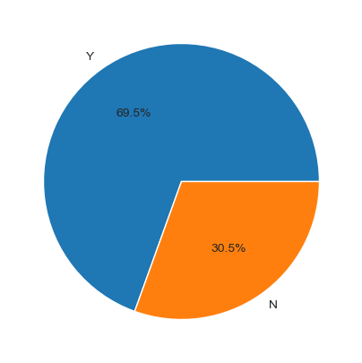

```
	- столбец NAME_TYPE_SUITE
```

|  | NAME_TYPE_SUITE |
| --- | --- |
| Unaccompanied | 81.1% |
| Family | 13.1% |
| Spouse, partner | 3.7% |
| Children | 1.1% |
| Other_B | 0.6% |
| Other_A | 0.3% |
| Group of people | 0.1% |

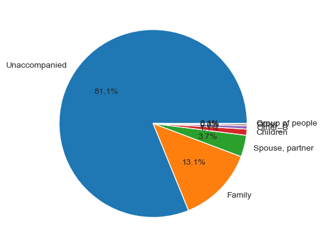

```
	- столбец NAME_INCOME_TYPE
```

|  | NAME_INCOME_TYPE |
| --- | --- |
| Working | 51.7% |
| Commercial associate | 23.2% |
| Pensioner | 18.0% |
| State servant | 7.1% |
| Unemployed | 0.0% |
| Student | 0.0% |
| Businessman | 0.0% |
| Maternity leave | 0.0% |

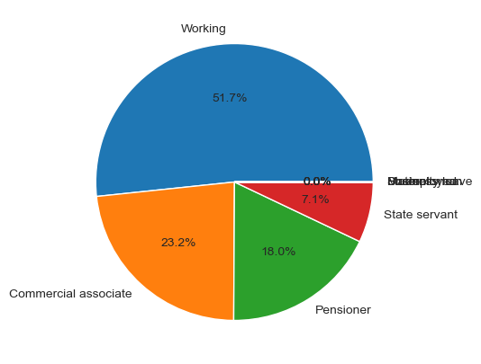

```
	- столбец NAME_EDUCATION_TYPE
```

|  | NAME_EDUCATION_TYPE |
| --- | --- |
| Secondary / secondary special | 71.1% |
| Higher education | 24.2% |
| Incomplete higher | 3.3% |
| Lower secondary | 1.2% |
| Academic degree | 0.1% |

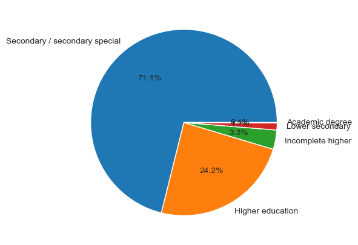

```
	- столбец NAME_HOUSING_TYPE
```

|  | NAME_HOUSING_TYPE |
| --- | --- |
| House / apartment | 88.7% |
| With parents | 4.8% |
| Municipal apartment | 3.6% |
| Rented apartment | 1.6% |
| Office apartment | 0.8% |
| Co-op apartment | 0.4% |

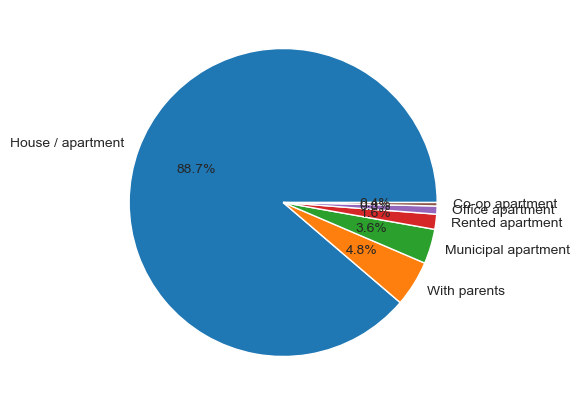

```python
# набор данных пора разделить
X = df_reduced.drop(columns=['TARGET']).copy()
y = df_reduced['TARGET'].copy()

# рассмотрим балансы классов категориальных и дискретных числовых признаков

print(f'\nБаланс классов целевого признака.\n')

_y = pd.DataFrame(y.value_counts(normalize=True, ascending=False))
display(_y.style.format('{:.1%}'))

plt.figure(figsize=(5,5))
plt.pie(_y['TARGET'],labels=_y.index,autopct='%1.1f%%')
plt.show()

print(f'\nБаланс классов категориальных признаков c круговыми диаграммами.\n')

for col in df_reduced.columns:
    if (df_reduced[col].dtype == 'object'):
        print(f'\t- столбец {col}')
        _t = pd.DataFrame(df_reduced[col].value_counts(normalize=True, ascending=False))
        display(_t.style.format('{:.1%}'))

        plt.figure(figsize=(5,5))
        plt.pie(_t[col],labels=_t.index,autopct='%1.1f%%')
        plt.show()
```

```python
# классы несбалансированные, частично учтём это при разделении выборки
X_train, X_test, y_train, y_test = (
    train_test_split(X, y, train_size = 0.7
                     , random_state=state, shuffle=True
                     , stratify=pd.concat([y, X[['CODE_GENDER','FLAG_EMAIL']]], axis=1))
)

X_train.shape, X_test.shape, y_train.shape, y_test.shape
```

```
((213171, 28), (91360, 28), (213171,), (91360,))
```

```python
# используя конвейеры подготовим данные для обучения и сожмём с пом. PCA

## описание для выбора категориальных и числовых данных
cat_features = make_column_selector(dtype_include=['object','int64'])
num_features = make_column_selector(dtype_exclude=['object','int64'])

## трансформеры для категориальных и числовых данных (параллельные)
ct_num = ColumnTransformer([
    ("num_preprocess", StandardScaler(), num_features)
], remainder='drop')

ct_cat = ColumnTransformer([
    ("cat_preprocess"
     , OrdinalEncoder(
         handle_unknown='use_encoded_value', unknown_value = -1
     )
     , cat_features)
], remainder='drop')

## преобразования данных из соотв. трансформмеров и сжатие PCA
num_pca_pipe = Pipeline([('num_prepr', ct_num), ('num_PCA', PCA(0.95))])
cat_pca_pipe = Pipeline([('cat_prepr', ct_cat),
                         #('cat_stand', MinMaxScaler()), #информ-ть масштабир. не повысило
                         ('cat_PCA', PCA(0.95))])

## объединение выходов с предыдущего шага в один набор данных для дальнейшего обучения
prepr_union = FeatureUnion([
    ('numeric', num_pca_pipe)
    ,('categorical', cat_pca_pipe)
])

## смаштабируем полученные признаки в ещё одном конвейре
pca_united_scaled = Pipeline([('features_union', prepr_union), ('std_scaler', StandardScaler())])

print('''\nИспользуя конвейеры и трансформеры, подготовим данные для обучения моделей:
- параллельно обработаем числовые и категориальные признаки (нормализация, кодирование),
- сократим пространство признаков с помощью PCA
- объединим резульаты обработки категор. и числовых признаков в один набор данных

В качестве примера перехода от исходного набора данных к итоговому рассмотрим в сокращении:

\t1. исх.данные (после удаления столбцов с пропусками):''')
display(df.sample(3))

print('\n\t2. данные перед PCA (после удаления столбцов в рез-ате корр.анализа и теста Фишера):')
display(X.sample(3))

print('\n\t3. данные после PCA (0.95)')
display(pd.DataFrame(pca_united_scaled.fit_transform(X_train)).sample(5))
```

```
Используя конвейеры и трансформеры, подготовим данные для обучения моделей:
- параллельно обработаем числовые и категориальные признаки (нормализация, кодирование),
- сократим пространство признаков с помощью PCA
- объединим резульаты обработки категор. и числовых признаков в один набор данных

В качестве примера перехода от исходного набора данных к итоговому рассмотрим в сокращении:

	1. исх.данные (после удаления столбцов с пропусками):
```

|  | SK_ID_CURR | TARGET | NAME_CONTRACT_TYPE | CODE_GENDER | FLAG_OWN_CAR | FLAG_OWN_REALTY | CNT_CHILDREN | AMT_INCOME_TOTAL | AMT_CREDIT | NAME_TYPE_SUITE | ... | FLAG_DOCUMENT_12 | FLAG_DOCUMENT_13 | FLAG_DOCUMENT_14 | FLAG_DOCUMENT_15 | FLAG_DOCUMENT_16 | FLAG_DOCUMENT_17 | FLAG_DOCUMENT_18 | FLAG_DOCUMENT_19 | FLAG_DOCUMENT_20 | FLAG_DOCUMENT_21 |
| --- | --- | --- | --- | --- | --- | --- | --- | --- | --- | --- | --- | --- | --- | --- | --- | --- | --- | --- | --- | --- | --- |
| 160842 | 286457 | 0 | Cash loans | M | N | Y | 0 | 225000.0 | 348264.0 | Unaccompanied | ... | 0 | 0 | 0 | 0 | 0 | 0 | 0 | 0 | 0 | 0 |
| 49217 | 156978 | 0 | Revolving loans | F | Y | Y | 1 | 112500.0 | 337500.0 | Unaccompanied | ... | 0 | 0 | 0 | 0 | 0 | 0 | 0 | 0 | 0 | 0 |
| 16592 | 119356 | 0 | Cash loans | F | N | Y | 1 | 126000.0 | 239850.0 | Unaccompanied | ... | 0 | 0 | 0 | 0 | 0 | 0 | 0 | 0 | 0 | 0 |

3 rows × 54 columns

```
	2. данные перед PCA (после удаления столбцов в рез-ате корр.анализа и теста Фишера):
```

|  | CODE_GENDER | FLAG_OWN_CAR | FLAG_OWN_REALTY | CNT_CHILDREN | AMT_INCOME_TOTAL | AMT_CREDIT | NAME_TYPE_SUITE | NAME_INCOME_TYPE | NAME_EDUCATION_TYPE | NAME_HOUSING_TYPE | ... | FLAG_EMAIL | REGION_RATING_CLIENT | HOUR_APPR_PROCESS_START | REG_REGION_NOT_LIVE_REGION | EXT_SOURCE_2 | OBS_30_CNT_SOCIAL_CIRCLE | DEF_30_CNT_SOCIAL_CIRCLE | DAYS_LAST_PHONE_CHANGE | FLAG_DOCUMENT_3 | FLAG_DOCUMENT_9 |
| --- | --- | --- | --- | --- | --- | --- | --- | --- | --- | --- | --- | --- | --- | --- | --- | --- | --- | --- | --- | --- | --- |
| 45145 | F | Y | Y | 2 | 180000.0 | 585000.0 | Unaccompanied | Commercial associate | Secondary / secondary special | House / apartment | ... | 0 | 2 | 10 | 0 | 0.355126 | 1.0 | 0.0 | -176.0 | 1 | 0 |
| 240536 | F | Y | N | 0 | 193500.0 | 1125000.0 | Unaccompanied | Working | Higher education | House / apartment | ... | 0 | 2 | 9 | 0 | 0.467776 | 3.0 | 0.0 | -837.0 | 1 | 0 |
| 195523 | F | N | N | 2 | 135000.0 | 640080.0 | Unaccompanied | Working | Secondary / secondary special | With parents | ... | 0 | 2 | 9 | 0 | 0.362728 | 0.0 | 0.0 | -2876.0 | 1 | 0 |

3 rows × 28 columns

```
	3. данные после PCA (0.95)
```

|  | 0 | 1 | 2 | 3 | 4 | 5 | 6 | 7 | 8 | 9 | 10 |
| --- | --- | --- | --- | --- | --- | --- | --- | --- | --- | --- | --- |
| 113307 | 0.172923 | 1.537808 | 1.737347 | 0.068851 | -0.433137 | -1.214798 | 0.319838 | -1.494337 | -1.398972 | 0.222427 | -0.083464 |
| 126654 | 0.626904 | -0.480860 | -1.048027 | 0.311785 | 1.683920 | -1.742225 | -0.221932 | -0.953761 | 0.675345 | -0.620734 | 1.758979 |
| 4710 | -1.586393 | -0.881988 | 0.498143 | -0.033867 | -0.009758 | -0.030378 | 0.039295 | -0.283571 | -1.503873 | -0.514782 | 0.219457 |
| 140366 | -1.350974 | -0.795001 | 0.337613 | 0.439697 | -0.110088 | 1.209401 | -0.187181 | -0.336357 | -1.457788 | 0.551788 | 0.925225 |
| 18404 | 0.204221 | -0.516310 | -0.719731 | -1.159909 | 0.357082 | -0.786945 | 0.741749 | 0.280659 | -0.917654 | -0.211931 | 1.408178 |

## Обучение моделей.

Перед началом исследования определимся с применяемыми ML-алгоритмами и метриками оценки эффективности моделей.

Для обучения будем пользоваться линейными и нелинейными моделями:

- ***логистической регрессией***,
- ***случайным лесом***,
- В качесиве базовой оценки примем ***константную модель*** (`DummyClassifier`).

В задаче классификации оперировать только метрикой **accuracy** будет недостаточно, нужно учитывать также изменения **precision** и **recall**. С этим вполне справится **F1-мера**, но поскольку она отражает среднее гармоническое оценок для конкретно выбранного порога чувствительности, то диапазон возможных изменений (для всех порогов) удобнее оценивать по **ROC-AUC**.

### Константная модель.

Получим оценку константной/случайной модели по результатам работы `DummyClassifier`, примем её за базовую. Последовательно передадим `DummyClassifier` гиперпараметры `strategy='uniform'` и `strategy='constant'`, чтобы получить случайную модель и константную, которая отвечает "1" независимо от значений на входе.

```python
%%time

# создадим словарь для хранения значений ROC-AUC мер
roc_auc_scores = {}

dummy_random = DummyClassifier(random_state=state, strategy='uniform')
dummy_const = DummyClassifier(random_state=state, strategy='constant', constant=1)

model = [dummy_random, dummy_const]
name = ['CЛУЧАЙНАЯ','КОНСТАНТНАЯ']

# цикл по 2 моделям
for i in range(len(model)):
    clf = Pipeline([           # Pipeline с предобработкой и моделью
        ('features_prepr', pca_united_scaled),
        ('estimator', model[i])
    ])

    # получение оценок моделей
    print(f'модель - {str(model[i])[:16]}...{str(model[i])[-20:-1]})')
    print(f'ROC-AUC мера модели ({name[i]}):',
          cross_val_score(clf,  X_train, y_train,
                          scoring='roc_auc', cv=5).mean(), '\n') # ROC-AUC после кросс-валидации

    # добавим результаты в словарь
    roc_auc_scores[f'{name[i]} модель'] = (
        cross_val_score(clf, X_train, y_train, scoring='roc_auc', cv=5).mean().round(4)
    )
```

```
модель - DummyClassifier(... strategy='uniform')
ROC-AUC мера модели (CЛУЧАЙНАЯ): 0.5

модель - DummyClassifier(...strategy='constant')
ROC-AUC мера модели (КОНСТАНТНАЯ): 0.5

Wall time: 18.6 s
```

### Логистическая регрессия.

Получив base-line решение, сравним его с результатами других моделей. ***Логистическая регрессия*** в этом списке первая. Результы работы модели со станд. настройками будут ужасающе низкими, подберём гиперпараметры с помощью методов оптимизации.

Лучшие гиперараметры найдём случайным поиском по сетке с кросс-валидацией (`RandomizedSearchCV`), поскольку он позволяет сильно экономить время на вычислениях:

- для устранения переобучения предполагается в основном варьировать параметром *C: Inverse of regularization strength*, чтобы достаточно понизить веса признаков на обучающей выборке,
- подбирать значение лучшего порога не станем.

```python
%%time

model = LogisticRegression(random_state=state)

# Pipeline с предобработкой и моделью
clf = Pipeline([
    ('features_prepr', pca_united_scaled),
    ('estimator', model)
])

# поиск лучших гиперпарметров по сетке с кросс-валидацией
grid = {
    'estimator__penalty': ['l1', 'l2', 'elasticnet'],
    'estimator__C': np.linspace(0.00001, 1000000, 1000),
    #'estimator__max_iter': range(100,1000,100),
    'estimator__class_weight': ['balanced', 'None'],
    'estimator__solver': ['saga', 'liblinear']
}

LR_clf = RandomizedSearchCV(
    clf,
    param_distributions=grid,
    random_state=state,
    n_iter=400,
    scoring='roc_auc',
    cv=4, verbose=2, n_jobs=-1
)

LR_clf.fit(X_train, y_train)

# из истории:
#- Лучший ROC-AUC =  0.67438
#- Лучшие параметры: {'solver': 'liblinear', 'penalty': 'l2', 'class_weight': 'balanced', 'C': 911191.1191127993}

# выведем результаты на экран:
print('\nЛогистическая регрессия\n')
print('- Лучший ROC-AUC = ', LR_clf.best_score_.round(5))
print('- Лучшие параметры:\n\t', {str(i)[11:]:LR_clf.best_params_.get(i) for i in LR_clf.best_params_})
print('- Лучшая модель:\n\t доступна из "LR_clf.best_estimator_"\n')

# добавим результаты в словарь
roc_auc_scores[f'Логистическоая регрессия'] = LR_clf.best_score_
```

```
Fitting 4 folds for each of 400 candidates, totalling 1600 fits

Логистическая регрессия

- Лучший ROC-AUC =  0.67631
- Лучшие параметры:
	 {'solver': 'liblinear', 'penalty': 'l1', 'class_weight': 'balanced', 'C': 758758.7587611713}
- Лучшая модель:
	 доступна из "LR_clf.best_estimator_"

Wall time: 8min 32s
```

Модель, построенная на основе логистической регрессии, дала прирост качества относительно случайного и константного классификаторов, но вполне успешным такой результат признать трудно, поскольку метрики получились плохими.

```python
%%time

## Альт.вариант логистич.регрессии:
## (РСА на всех признаках, нет итогового масштабирования всех признаков)

model = LogisticRegression(random_state=state)

# новый Pipeline с предобработкой и моделью
clf_1 = Pipeline([
    ('features_prepr_pca_nonsclaed', prepr_union),
    ('estimator', model)
])

# поиск лучших гиперпарметров по сетке с кросс-валидацией
grid = {
    'estimator__penalty': ['l1', 'l2', 'elasticnet'],
    'estimator__C': np.linspace(0.00001, 1000000, 10000),
    #'estimator__max_iter': range(100,1000,100),
    'estimator__class_weight': ['balanced', 'None'],
    'estimator__solver': ['saga', 'liblinear']
}

# новый классификатор
LR_clf_1 = RandomizedSearchCV(
    clf_1,
    param_distributions=grid,
    random_state=state,
    n_iter=100,
    scoring='roc_auc',
    cv=4, verbose=1, n_jobs=-1
)

LR_clf_1.fit(X_train, y_train)

# выведем результаты на экран:
print('\nЛогистическая регрессия\n')
print('- Лучший ROC-AUC = ', LR_clf_1.best_score_.round(5))
print('- Лучшие параметры:\n\t', {str(i)[11:]:LR_clf_1.best_params_.get(i) for i in LR_clf_1.best_params_})
print('- Лучшая модель:\n\t доступна из "LR_clf_1.best_estimator_"\n')

# добавим результаты в словарь
#roc_auc_scores[f'Логистическоая регрессия'] = LR_clf_1.best_score_
```

```
Fitting 4 folds for each of 100 candidates, totalling 400 fits

Логистическая регрессия

- Лучший ROC-AUC =  0.67631
- Лучшие параметры:
	 {'solver': 'liblinear', 'penalty': 'l1', 'class_weight': 'balanced', 'C': 34503.45035468948}
- Лучшая модель:
	 доступна из "LR_clf_1.best_estimator_"

Wall time: 5min 16s
```

```python
%%time

## Альт.вариант логистич.регрессии:
## (РСА+нормализация на колич. признаках, категориальные только перекодированы)

# новый трансформер для объединения категориальных и числовых признаков после обработки
prepr_union_1 = FeatureUnion([
    ('numeric', num_pca_pipe)
    ,('categorical_nonpca', ct_cat)
])

# новый Pipeline с предобработкой и моделью
clf_2 = Pipeline([
    ('features_prepr_pca_nonsclaed', prepr_union_1),
    ('estimator', model)
])

# поиск лучших гиперпарметров по сетке с кросс-валидацией
grid = {
    'estimator__penalty': ['l1'],
    'estimator__C': np.linspace(100000, 200000, 100),
    #'estimator__max_iter': range(100,1000,100),
    'estimator__class_weight': ['balanced'],
    'estimator__solver': ['liblinear']
}

LR_clf_2 = RandomizedSearchCV(
    clf_2,
    param_distributions=grid,
    random_state=state,
    n_iter=50,
    scoring='roc_auc',
    cv=4, verbose=1, n_jobs=-1
)

LR_clf_2.fit(X_train, y_train)

# из истории:
#- Лучший ROC-AUC =  0.69631
#- Лучшие параметры: {'solver': 'liblinear', 'penalty': 'l1', 'class_weight': 'balanced', 'C': 122912.2912378938}

# выведем результаты на экран:
print('\nЛогистическая регрессия\n')
print('- Лучший ROC-AUC = ', LR_clf_2.best_score_.round(5))
print('- Лучшие параметры:\n\t', {str(i)[11:]:LR_clf_2.best_params_.get(i) for i in LR_clf_2.best_params_})
print('- Лучшая модель:\n\t доступна из "LR_clf_2.best_estimator_"\n')

# добавим результаты в словарь
roc_auc_scores[f'Логистическоая регрессия_2'] = LR_clf_2.best_score_
```

```
Fitting 4 folds for each of 50 candidates, totalling 200 fits

Логистическая регрессия

- Лучший ROC-AUC =  0.69681
- Лучшие параметры:
	 {'solver': 'liblinear', 'penalty': 'l1', 'class_weight': 'balanced', 'C': 177777.77777777775}
- Лучшая модель:
	 доступна из "LR_clf_2.best_estimator_"

Wall time: 1h 39min 7s
```

Использование **RandomizedSearchCV** для настройки гиперпараметров модели вместо перебора всех вариантов по сетке **GridSearchCV** даёт заметный и прогнозируемый выигрыш в скорости выполнения. Это по-прежнему удивительно, а благодаря теории вероятностей и ЦПТ результаты вдобавок получаются близкими по качеству.

### K-ближайших соседей.

Обучение модели с помощью алгоритма Взвешенных K-ближайших соседей изначально не рассматривалось по причине величины выборки, но было выполнено "из спортивного интереса" в сокращённом формате.

Основной проблемой является трудоёмкость вычислений для алгоритмов, основанных на метрических расстояниях. Результаты, может, и будут достигаться лучшие, но простое запоминание и расчёт расстояний для каждого объекта в случае большой выборки крайне замедлит процесс получения результатов и будут очень ресурсоёмкими. В качестве выхода можно пробовать дальнейшее снижение размерности, но подробно этот вопрос не исследовался в данной работе.

```python
%%time

model = KNeighborsClassifier()

# новый Pipeline с предобработкой и моделью, признаки дополнительно сжимаются

## повторное сжатие PCA
add_pca_pipe = Pipeline([('pca_united_scaled', pca_united_scaled),
                         ('add_PCA', PCA(0.8))])
# Pipeline
clf = Pipeline([
    ('features_prepr_pca_plus', add_pca_pipe),
    ('estimator', model)
])

# поиск лучших гиперпарметров по сетке с кросс-валидацией
grid = {
    'estimator__n_neighbors': range(10,41,5),
    'estimator__weights': ['distance', lambda x: 1/(x+1)],
    'estimator__algorithm': ['auto'],
    'estimator__leaf_size': range(30,101,15),
    'estimator__p': [2]
}

KNС_clf = RandomizedSearchCV(
    clf,
    param_distributions=grid,
    random_state=state,
    n_iter=20,
    scoring='roc_auc',
    cv=3, verbose=1, n_jobs=-1
)

KNС_clf.fit(X_train, y_train)

# из истории:
#- Лучший ROC-AUC =  0.64263
#- Лучшие параметры: {'weights': 'distance', 'p': 2, 'n_neighbors': 50, 'leaf_size': 65, 'algorithm': 'auto'}

# выведем результаты на экран:
print('\nK-ближайших соседей\n')
print('- Лучший ROC-AUC = ', KNС_clf.best_score_.round(5))
print('- Лучшие параметры:\n\t', {str(i)[11:]:KNС_clf.best_params_.get(i) for i in KNС_clf.best_params_})
print('- Лучшая модель:\n\t доступна из "KNС_clf.best_estimator_"\n')

# добавим результаты в словарь
roc_auc_scores[f'Взвешенный K-ближайших соседей'] = KNС_clf.best_score_
```

```
Fitting 3 folds for each of 20 candidates, totalling 60 fits

K-ближайших соседей

- Лучший ROC-AUC =  0.64007
- Лучшие параметры:
	 {'weights': <function <lambda> at 0x000001DC8574C8B0>, 'p': 2, 'n_neighbors': 40, 'leaf_size': 75, 'algorithm': 'auto'}
- Лучшая модель:
	 доступна из "KNС_clf.best_estimator_"

Wall time: 6h 53min 37s
```

### Случайный лес

Бустинговые и нейросетевые алгоритмы в данной работе не рассматривались и для поиска вариантов улучшения остаётся воспользоваться ансамблевыми методами. В данном случае ***случайным лесом***.

Хотя бэггинговый классификатор над деревьями и обладает явными достоинствами в виде нечувствительности к масштабам данных, небольшим числом значимых гиперпараметров и способностью воспроизводить закономерности данных, но ресурсоёмкоесть вычислений на выборке подобного объёма будет велика (по крайней мере для домашнего ПК автора).

- Вдобавок, из-за **PCA**-алгоритма и получающейся преобразованной выборки, про интерпретируемость результатов говорить не приходится. Что при хорошем качестве предсказаний можно было бы принять как данность.
- Дождаться окончания обучения простой модели (со станд. настройками ГП) и на полноразмерной тренировочной выборке за приемлемое время при первом запуске не удалось вовсе, поэтому были предприняты попытки для уменьшения влияния большой размерности.
- В итоге модели обучались на нескольких выборках для поиска баланса между временем расчёта и качеством:
  - на сокращённой и полной выборке
  - с признаками в исходном виде (без сжатия, без масштабирования, с порядковым кодированием переменных вместо прямого, т.к. деревья прекрасно работают и с ним) так и с обработанной выборкой (сжатие, двойное сжатие, масштабирование).

- Отдельно хочется отметить ценность кросс-валидации при поиске ГП как инструмента, позволяющего получать адекватные и устойчивые оценки качества моделей уже на тренировочной выборке. Без кросс-валидации модели легко переобучаются на всём объёме данных и на тестовой выборке делают предсказания близкие к случайным.

```python
%%time

model = RandomForestClassifier(random_state=state)

## Базовый вариант со случ.лесом:
## (РСА и нормализации нет, колич.признаки в исходном виде, категориальные-перекодированы)

# новый трансформер для категориальных и числовых признаков после обработки
ct_cat_num = ColumnTransformer([
    ("cat_preprocess"
     , OrdinalEncoder(handle_unknown='use_encoded_value', unknown_value = -1)
     , cat_features)
], remainder='passthrough')

# новый Pipeline с предобработкой и моделью
clf_rf = Pipeline([
    ('features_prepr_non_pca_non_scaled', ct_cat_num),
    ('estimator', model)
])

# поиск лучших гиперпарметров по сетке с кросс-валидацией
grid = {
    'estimator__n_estimators': range(400, 551, 10),
    'estimator__criterion': ['gini'],
    'estimator__max_depth': range(20, 41, 5),
    'estimator__class_weight': ['balanced', None],
    #'estimator__max_leaf_nodes': range(1, 101, 2)
}

RF_clf = RandomizedSearchCV(
    clf_rf,
    param_distributions=grid,
    random_state=state,
    n_iter=2,
    scoring='roc_auc',
    cv=4, verbose=1, n_jobs=-1
)

RF_clf.fit(X_train, y_train)

# из истории:
#- Лучший ROC-AUC =  0.693
#- Лучшие параметры: {'n_estimators': 500, 'max_depth': 50, 'criterion': 'gini', 'class_weight': 'balanced'}

# выведем результаты на экран:
print('\nСлучайный лес\n')
print('- Лучший ROC-AUC = ', RF_clf.best_score_.round(5))
print('- Лучшие параметры:\n\t', {str(i)[11:]:RF_clf.best_params_.get(i) for i in RF_clf.best_params_})
print('- Лучшая модель:\n\t доступна из "RF_clf.best_estimator_"\n')

# добавим результаты в словарь
roc_auc_scores[f'Случайный лес'] = RF_clf.best_score_
```

```
Fitting 4 folds for each of 2 candidates, totalling 8 fits

Случайный лес

- Лучший ROC-AUC =  0.69058
- Лучшие параметры:
	 {'n_estimators': 510, 'max_depth': 25, 'criterion': 'gini', 'class_weight': 'balanced'}
- Лучшая модель:
	 доступна из "RF_clf.best_estimator_"

Wall time: 10min 38s
```

```python
%%time

model = RandomForestClassifier(random_state=state)

## Альт.вариант со случайным лесом:
## (РСА и нормализации на всех признаках (однократно, на колич. и категор. по-отдельности)

# первоначальный Pipeline с предобработкой (кодирование+РСА+нормализация) и моделью
clf = Pipeline([
    ('features_prepr', pca_united_scaled),
    ('estimator', model)
])

# поиск лучших гиперпарметров по сетке с кросс-валидацией
grid = {
    'estimator__n_estimators': range(400, 501, 20),
    'estimator__criterion': ['gini'],
    'estimator__max_depth': range(20, 71, 10),
    'estimator__class_weight': ['balanced', None],
    #'estimator__max_leaf_nodes': range(1, 101, 2)
}

RF_clf = RandomizedSearchCV(
    clf,
    param_distributions=grid,
    random_state=state,
    n_iter=1,
    scoring='roc_auc',
    cv=4, verbose=1, n_jobs=-1
)

RF_clf.fit(X_train[:200000], y_train[:200000])

#print(accuracy_score(y_train[:100000], clf_rf.predict(X_train[:100000])))
#print(f1_score(y_train[:100000], clf_rf.predict(X_train[:100000])))
#print(roc_auc_score(y_train[:100000], clf_rf.predict(X_train[:100000])))

# выведем результаты на экран:
print('\nЛогистическая регрессия\n')
print('- Лучший ROC-AUC = ', RF_clf.best_score_.round(5))
print('- Лучшие параметры:\n\t', {str(i)[11:]:RF_clf.best_params_.get(i) for i in RF_clf.best_params_})
print('- Лучшая модель:\n\t доступна из "RF_clf.best_estimator_"\n')

# добавим результаты в словарь
#roc_auc_scores[f'Случайный лес'] = RF_clf.best_score_
```

```
Fitting 4 folds for each of 1 candidates, totalling 4 fits

Логистическая регрессия

- Лучший ROC-AUC =  0.66168
- Лучшие параметры:
	 {'n_estimators': 420, 'max_depth': 70, 'criterion': 'gini', 'class_weight': 'balanced'}
- Лучшая модель:
	 доступна из "RF_clf.best_estimator_"

Wall time: 9min 48s
```

- Результаты иногда становятся лучше достижений логистической регрессии, но их получение было значительно более трудоёмкое. Хотя результат и получился довольно посредственный, остановимся тем не менее на имеющихся, чтобы по крайней мере можно было завершить исследование.
- Модель явно можно улучшить подбором гиперпараметров, а также настройкой порога классификации, но эта деятельность в рамки учебной работы не вошла из-за временных и ресурсных ограничений.

## Результаты на тестовой выборке, выводы.

Сравним оценки моделей на отложенной тестовой выборке и составим выводы с использованием матрицы ошибок/отчётов о классификации и значимости признаков.

```python
# соберём результаты в общий датафрейм

# ROC-AUC построенных моделей
print('ROC-AUC построенных моделей:')
roc_auc_df = (
    pd.DataFrame.from_dict(roc_auc_scores,
                           orient='index',
                           columns=['ROC-AUC_train+cv'])
    .sort_values(by='ROC-AUC_train+cv', ascending=True)
    .round(4)
)

# соберём ROC-AUC моделей на тестовой выборке и добавим его столбцом в датафрейм roc_auc_df
dummy = (
    Pipeline([
        ('prepr', pca_united_scaled),
        ('estimator', DummyClassifier(random_state=state, strategy='uniform'))
    ])
    .fit(X_train, y_train)
)

roc_auc_test = (                                                        ##ROC-AUC-score
    [roc_auc_score(y_test, dummy.predict(X_test))                       ## случайной модели
     , 0.5                                                              ## константной модели
     , roc_auc_score(y_test, KNС_clf.best_estimator_.predict(X_test))   ## K-ближайших
     , roc_auc_score(y_test, LR_clf.best_estimator_.predict(X_test))    ## логистич.регрессии
     , roc_auc_score(y_test, RF_clf.best_estimator_.predict(X_test))    ## cлучайного леса
     , roc_auc_score(y_test, LR_clf_2.best_estimator_.predict(X_test))] ## логистич.регрессии
)

roc_auc_df['ROC-AUC_test'] =  pd.Series(roc_auc_test, index=roc_auc_df.index)
roc_auc_df
```

```
ROC-AUC построенных моделей:
```

|  | ROC-AUC_train+cv | ROC-AUC_test |
| --- | --- | --- |
| CЛУЧАЙНАЯ модель | 0.5000 | 0.508340 |
| КОНСТАНТНАЯ модель | 0.5000 | 0.500000 |
| Взвешенный K-ближайших соседей | 0.6401 | 0.499970 |
| Логистическоая регрессия | 0.6763 | 0.630344 |
| Случайный лес | 0.6906 | 0.500370 |
| Логистическоая регрессия_2 | 0.6968 | 0.647055 |

**Выводы:**

- Оценки на тестовой выборке снилизись, что естественно.
- Видно, что случайный лес обучить не удалось, лучшим по-прежнему остаётся результат логистической регрессии, он оказался наиболее устойчивым.
- Возникает подозрение, что при обилии признаков и объектов проще сразу использовать бустинговые модели, которые обучаются с компенсацией ошибок или нейронные сети (правда насколько мне известно для табличных данных каких-то общепринятых архитектур не существует), чем подбирать ГП, т.к. этот процесс трудоёмок и требует времени.

### Значимость признаков и модификация лучшей модели.

В данной работе нет принципиального требования улучшить результаты, поэтому просто дополнительно взглянем на значимость признаков полученной модели и проанализируем матрицу ошибок классификации на тестовой выборке.

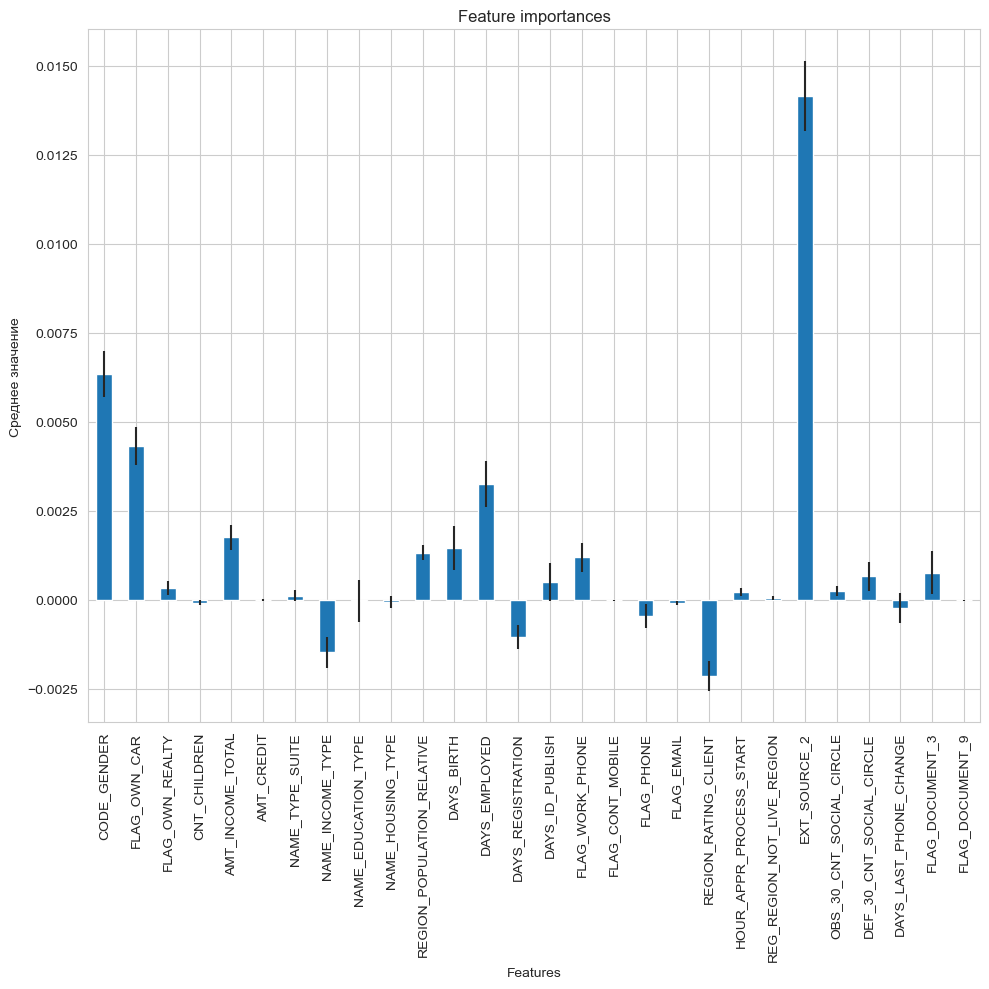

```python
# построим график значимости признаков на основе permutation_importance
features_names = X_test.columns #названия столбцов

# получение словаря с permutation_importance
result = (
    permutation_importance(
        LR_clf_2.best_estimator_
        , X_test, y_test
        , n_repeats=100
        , random_state=state)
)

# преобразуем в pd.Series для построения гистограммы
model_importances = pd.Series(result['importances_mean'], index=features_names)

# построение гистограммы значений со станд. отклонением
fig, ax = plt.subplots(figsize=(10,10))
model_importances.plot.bar(yerr=result['importances_std'], ax=ax, rot=90)
ax.set_title("Feature importances")
ax.set_ylabel("Среднее значение")
ax.set_xlabel("Features")
fig.tight_layout()
plt.show()
```

**Вывод**:

- Оценка качества моделей в принципе невысока, выдающихся результатов достигнуто не было, значимость признаков неравномерна и не слишком велика.
- можно видеть, что далеко не все признаки оказались полезными для предсказаний модели. Некоторые и вовсе вносят отрицательный вклад в результат. В дальнейшем можно пробовать упростить модель, исключив малозначимые признаки и признаки с отрицательным вкладом (либо попробовать учитывать их с обратным знаком).
- Но есть предположение, что наличие категориальных признаков и использование **PCA**, преобразующего значения нелинейно, обойтись изменением знака, описанными выше, не позволят. Хотя широкое использование `FunctionTransformer` и `make_column_selector` для создания своих конвейеров и трансформеров обработки признаков меня очень впечатлило получающейся в результате гибкостью.

```python
# удалим отрицательно- и малозначимые признаки
# подготовим список соотв. столбцов
mi_minus = model_importances[model_importances<=0.00025].index
mi_minus
```

```
Index(['CNT_CHILDREN', 'AMT_CREDIT', 'NAME_TYPE_SUITE', 'NAME_INCOME_TYPE',
       'NAME_EDUCATION_TYPE', 'NAME_HOUSING_TYPE', 'DAYS_REGISTRATION',
       'FLAG_CONT_MOBILE', 'FLAG_PHONE', 'FLAG_EMAIL', 'REGION_RATING_CLIENT',
       'HOUR_APPR_PROCESS_START', 'REG_REGION_NOT_LIVE_REGION',
       'OBS_30_CNT_SOCIAL_CIRCLE', 'DAYS_LAST_PHONE_CHANGE',
       'FLAG_DOCUMENT_9'],
      dtype='object')
```

```python
# признаки удалим вручную
X_train_mod = X_train.drop(columns=mi_minus).copy()
X_test_mod = X_test.drop(columns=mi_minus).copy()
```

```python
%%time

## Альт.вариант логистич.регрессии:
## (сокращённая после получения оценок значимости признаков)

model = LogisticRegression(random_state=state)

# оптимизация гиперпарметров по сетке "родительской" модели
grid = {
    'estimator__penalty': ['l1'],
    'estimator__C': np.linspace(104000, 125000, 20),
    #'estimator__max_iter': range(100,1000,100),
    'estimator__class_weight': ['balanced'],
    'estimator__solver': ['liblinear']
}

LR_clf_2_mod = RandomizedSearchCV(
    clf_2,
    param_distributions=grid,
    random_state=state,
    n_iter=10,
    scoring='roc_auc',
    cv=4, verbose=1, n_jobs=-1
)

LR_clf_2_mod.fit(X_train_mod, y_train)

# выведем результаты на экран:
print('\nЛогистическая регрессия\n')
print('- Лучший ROC-AUC = ', LR_clf_2_mod.best_score_.round(5))
print('- Лучшие параметры:\n\t', {str(i)[11:]:LR_clf_2_mod.best_params_.get(i) for i in LR_clf_2_mod.best_params_})
print('- Лучшая модель:\n\t доступна из "LR_clf_2_mod.best_estimator_"\n')
```

```
Fitting 4 folds for each of 10 candidates, totalling 40 fits

Логистическая регрессия

- Лучший ROC-AUC =  0.68899
- Лучшие параметры:
	 {'solver': 'liblinear', 'penalty': 'l1', 'class_weight': 'balanced', 'C': 104000.0}
- Лучшая модель:
	 доступна из "LR_clf_2_mod.best_estimator_"

Wall time: 1min 31s
```

```python
# оценка модифицированной "облегчённой" модели на тесте
roc_auc_score(y_test, LR_clf_2_mod.predict(X_test_mod))
```

```
0.6408153174613395
```

Несколько жертвуя качеством можно продолжить сокращать кол-во используемых признаков, скорость работы моделей при этом возрастёт за счёт снижения нагрузки.

### Матрица ошибок лучшей модели.

Ниже взглянем на матрицу ошибок лучшей модели.

```
Матрица мер классов целевого признака (на тестовой выборке):

              precision    recall  f1-score   support

     class 0       0.95      0.66      0.78     83960
     class 1       0.14      0.63      0.23      7400

    accuracy                           0.66     91360
   macro avg       0.55      0.65      0.51     91360
weighted avg       0.89      0.66      0.74     91360


Матрица ошибок (на тестовой выборке):
```

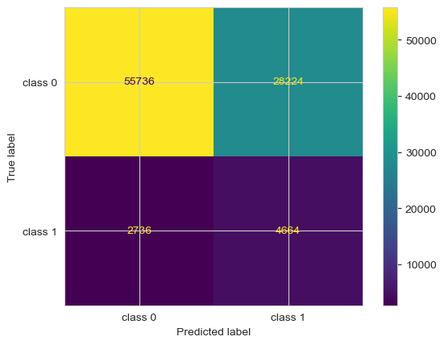

```python
# classification_report
y_true = y_test
y_pred = LR_clf_2.best_estimator_.predict(X_test)
target_names = ['class 0', 'class 1']
print('Матрица мер классов целевого признака (на тестовой выборке):\n')
print(classification_report(y_true, y_pred, target_names=target_names))
#print(confusion_matrix(y_true, y_pred))

# матрица ошибок
print('\nМатрица ошибок (на тестовой выборке):')
ConfusionMatrixDisplay(confusion_matrix(y_true, y_pred), display_labels=target_names).plot()
plt.show()
```

В представленной модели результаты не видятся слишком удачными: очень много ложно положительных срабатываний, что говорит о возможности улучшения в дальнейшем.

**Вывод**:

- Дисбаланс классов влияет на результаты предсказаний модели.
- Зная о преимущественном характере ложных срабатываний модели, можно скорректировать её поведение различными способами (сдвига порога, взвешивание классов при обучении, подбор ГП).
- При подготовке признаков сокращение размерности и нормализация числовых значений позволяют хотя бы приступить к этапу обучения моделей на локальной машине, что уже можно признать полезным. Большие наборы данных имеет смысл подготавливать именно способом уменьшения размерности признакового пространства, а также скорее всего использовать бустинговые модели.